# Reproducible Research: Peer Assessment 1

## Loading and preprocessing the data

Show any code that is needed to

1.Load the data (i.e. read.csv()) 2. Process/transform the data (if necessary) into a format suitable for your analysis

```r
library("ggplot2")
library("data.table")
library("lubridate")

steps <- fread("./data/activity.csv", header = T, sep = ",")
steps$date <- ymd(steps$date)

# knitr has some weird interactions with data.table, hence assignment to
# 'knitrbug'. Also some data.table stuff might be a bit hard to read - knitr
# re-indents :(

knitrbug <- steps[, `:=`(datetime, sprintf("%04d", interval))]
knitrbug <- steps[, `:=`(datetime, sub("(\\d{1,2})(\\d{2})$", "\\1:\\2", datetime))]
knitrbug <- steps[, `:=`(datetime, date + hm(datetime))]
knitrbug <- steps[, `:=`(steps, as.numeric(steps))]
```

## What is mean total number of steps taken per day?

1.Make a histogram of the total number of steps taken each day

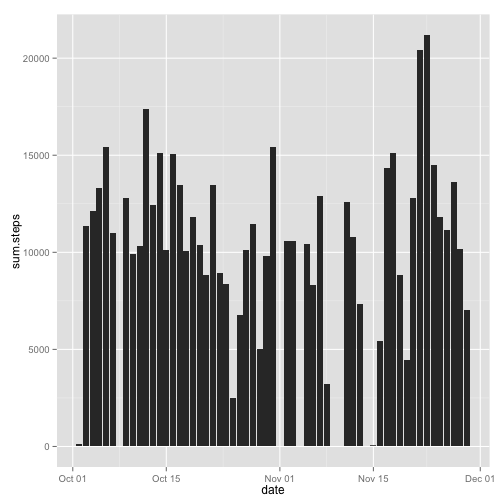

```r
qplot(date, sum.steps, data = steps[!is.na(steps), list(sum.steps = sum(steps)),
    by = date], geom = "bar", stat = "identity")
```

2.Calculate and report the mean and median total number of steps taken per day

```r
steps[, j = list(steps = sum(steps)), by = date][, j = list(mean = mean(steps,
    na.rm = T), median = as.double(median(steps, na.rm = T)))]
```

```
##     mean median
## 1: 10766  10765
```

## What is the average daily activity pattern?

Make a time series plot (i.e. type = “l”) of the 5-minute interval (x-axis) and the average number of steps taken, averaged across all days (y-axis)

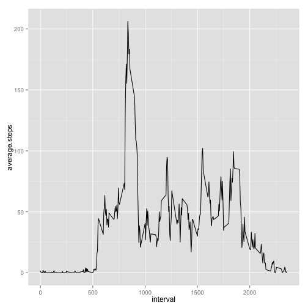

```r
qplot(x = interval, y = average.steps, data = steps[, j = list(average.steps = mean(steps,
    na.rm = T)), by = interval], geom = "line")
```

Which 5-minute interval, on average across all the days in the dataset, contains the maximum number of steps?

```r
steps[, j = list(average.steps = mean(steps, na.rm = T)), by = interval][which.max(average.steps),
    ]
```

```
##    interval average.steps
## 1:      835         206.2
```

## Imputing missing values

1.Calculate and report the total number of missing values in the dataset (i.e. the total number of rows with NAs)

```r
nrow(steps[is.na(steps), ])
```

```
## [1] 2304
```

2.Devise a strategy for filling in all of the missing values in the dataset. The strategy does not need to be sophisticated. For example, you could use the mean/median for that day, or the mean for that 5-minute interval, etc.

*I've used the mean for the 5-minute interval*

Make a histogram of the total number of steps taken each day and Calculate and report the mean and median total number of steps taken per day. Do these values differ from the estimates from the first part of the assignment?

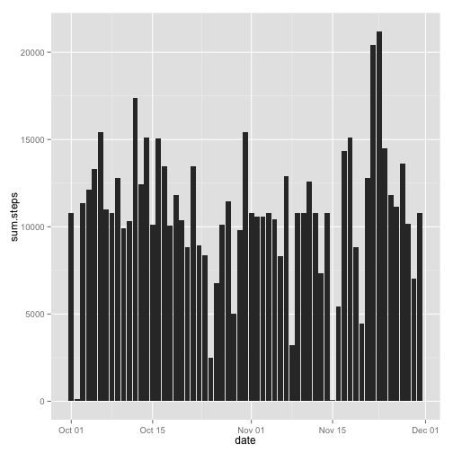

```r
knitrbug <- steps[, `:=`(int.mean.steps, mean(steps, na.rm = T)), by = interval]
knitrbug <- steps[is.na(steps), `:=`(steps, int.mean.steps)]
qplot(date, sum.steps, data = steps[, list(sum.steps = sum(steps)), by = date],
    geom = "bar", stat = "identity")
```

What is the impact of imputing missing data on the estimates of the total daily number of steps?

```r
steps[, j = list(steps = sum(steps)), by = date][, j = list(`new mean` = mean(steps,
    na.rm = T), `new median` = as.double(median(steps, na.rm = T)))]
```

```
##    new mean new median
## 1:    10766      10766
```

*Impact looks quite limited, at least when looking on daily average and mean.*

## Are there differences in activity patterns between weekdays and weekends?

Make a panel plot containing a time series plot (i.e. type = “l”) of the 5-minute interval (x-axis) and the average number of steps taken, averaged across all weekday days or weekend days (y-axis).

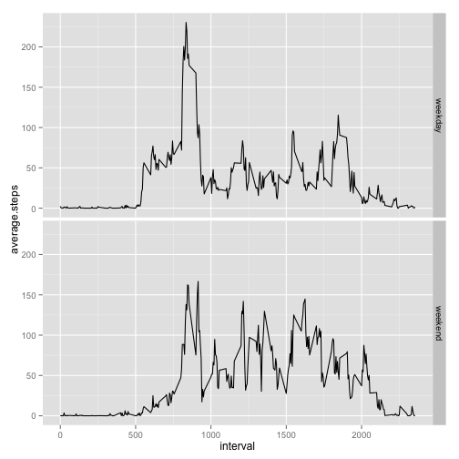

```r
knitrbug <- steps[, `:=`(weekend, ifelse(weekdays(date) %in% c("Saturday", "Sunday"),
    "weekend", "weekday"))]
knitrbug <- steps[, `:=`(weekend, as.factor(weekend))]
qplot(x = interval, y = average.steps, data = steps[, j = list(average.steps = mean(steps,
    na.rm = T)), by = list(interval, weekend)], geom = "line", facets = weekend ~
    .)
```